# Your Turn Solutions

Heike Hofmann

May, 2018

## Graphics Intro

Load the BRFSS subset for Iowa in 2012

```r
iowa <- read.csv("https://raw.githubusercontent.com/heike/summerschool-2018/master/02-graphics/data/brfss-iowa-2012.csv")
```

1. Use `qplot` to build a scatterplot of variables `WTKG3` (weight in kg) and `HTIN4` (height in inch)

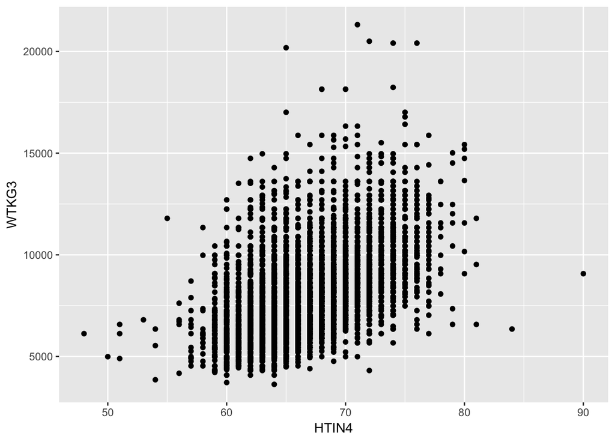

```r
library(ggplot2)
qplot(data = iowa, x = HTIN4, y = WTKG3)
```

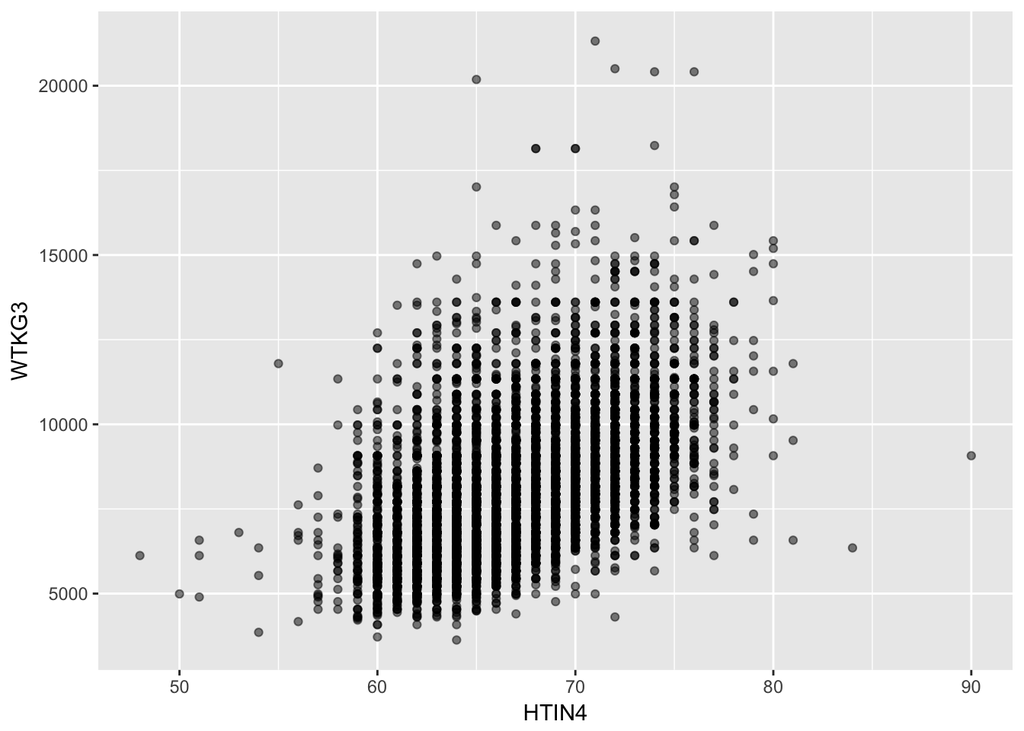

```r
# use some alpha blending to alleviate over-plotting
qplot(data = iowa, x = HTIN4, y = WTKG3, alpha = I(0.5))
```

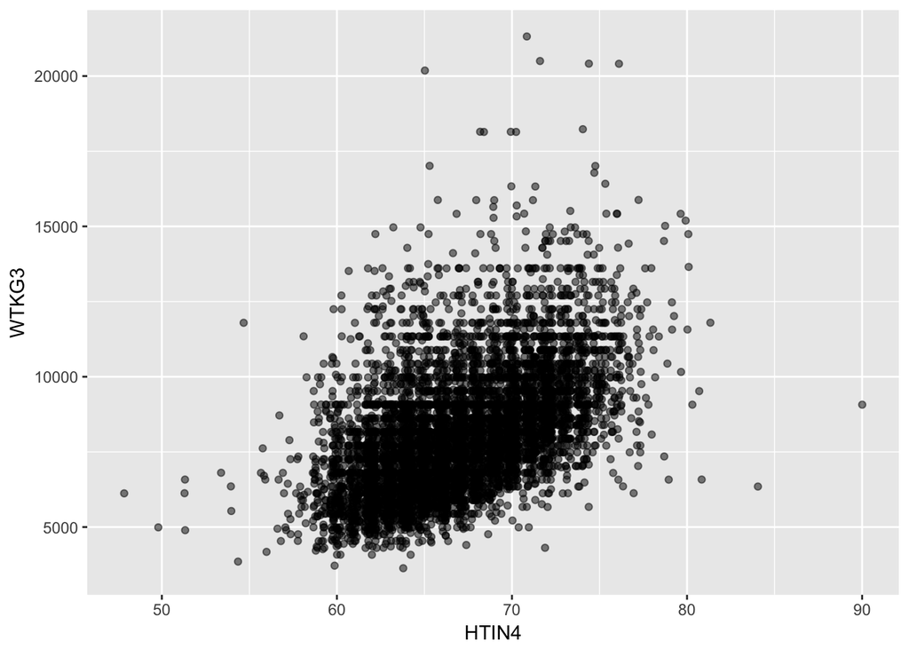

```r
# Generally there is a positive relationship, but it's not very strong, and there are lots of outliers on the upper end of the weight.
# The stripes come from height being reported in inch. We can use jittering to add some random noise

qplot(data = iowa, x = HTIN4, y = WTKG3, alpha = I(0.5), geom="jitter")
```

2. Use options within `qplot` to color points by a person’s gender (`SEX`)

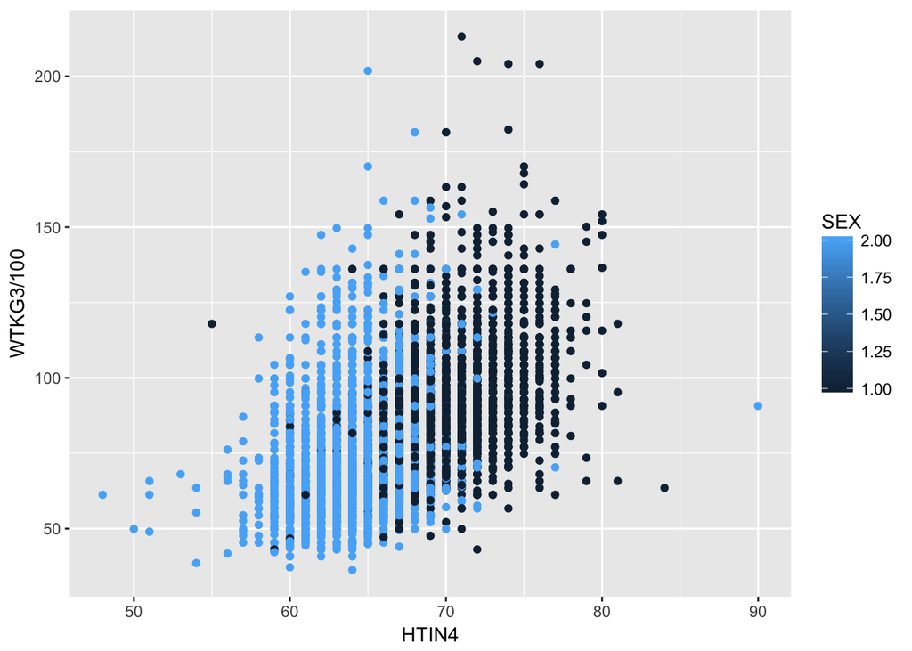

```r
qplot(data = iowa, x = HTIN4, y = WTKG3/100, colour = SEX)
```

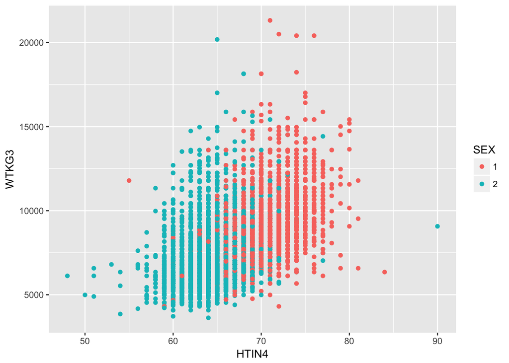

```r
# the colour is strange - let's change the SEX variable to a factor permanently:
iowa$SEX <- factor(iowa$SEX)

qplot(data=iowa, x = HTIN4, y = WTKG3, colour = SEX)
```

3. Clean up axis labels and add main plot title

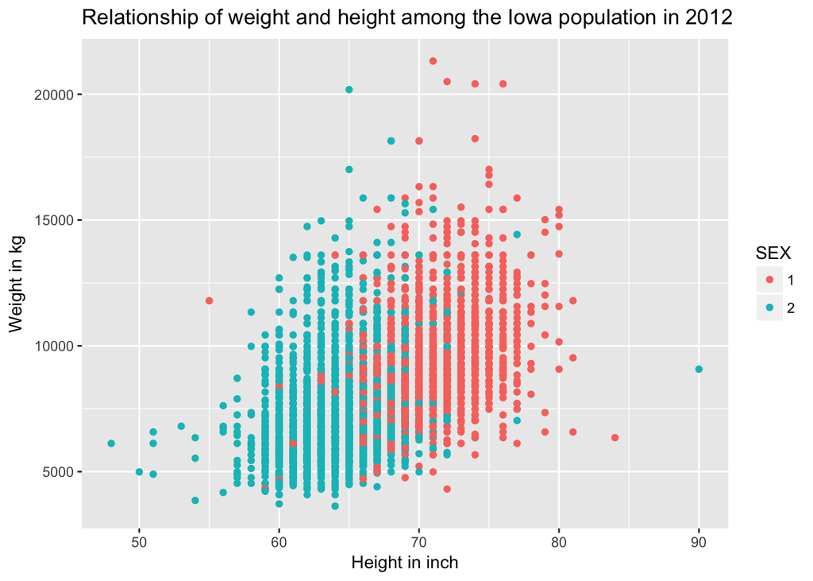

```r
qplot(data = iowa, x = HTIN4, y = WTKG3, colour = SEX) +
  ggtitle("Relationship of weight and height among the Iowa population in 2012") +
  xlab("Height in inch") +
  ylab("Weight in kg")
```

```r
iowa$bmi <- (iowa$WTKG3/100)/(iowa$HTIN4*2.54/100)^2
summary(iowa$bmi)
```

```
##    Min. 1st Qu.  Median    Mean 3rd Qu.    Max.    NA's
##   12.88   23.78   27.20   28.05   31.19   74.05     391
```

2. Use qplot to create a histogram of bmi

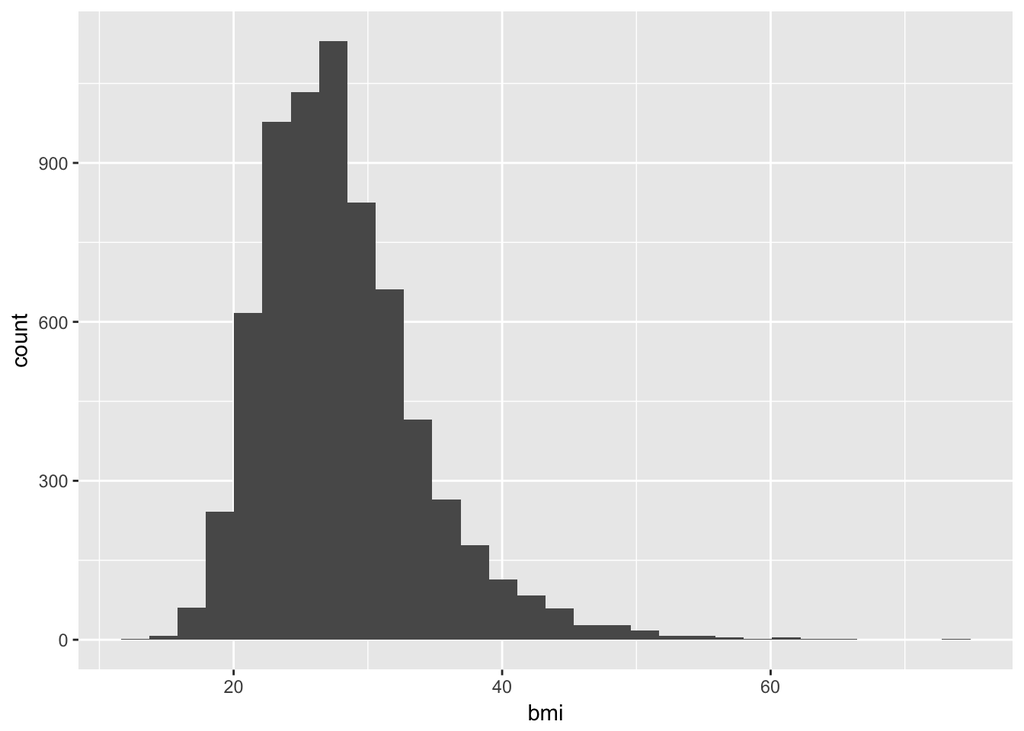

```r
qplot(data = iowa, x = bmi, geom="histogram")
```

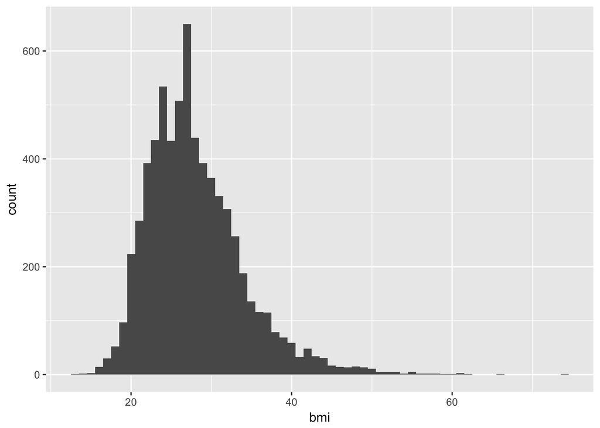

```r
qplot(data = iowa, x = bmi, geom="histogram", binwidth=1)
```

4. Facet this histogram by gender

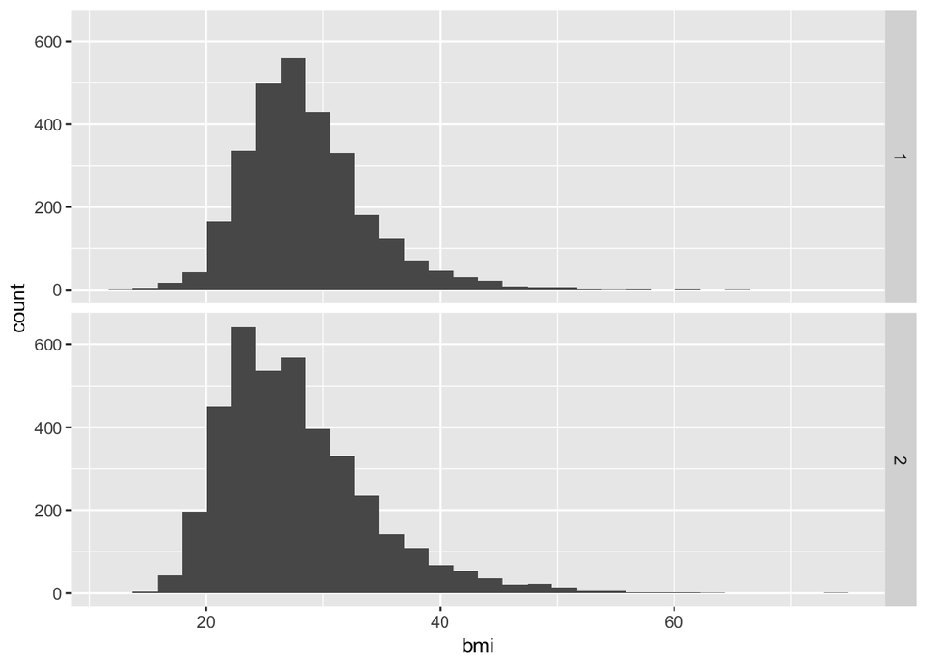

```r
qplot(data = iowa, x = bmi, geom="histogram", facets = SEX~.)
```

## Binge Drinking

1. The variable `DRNK3GE5` captures the number of times in the last 30 days that respondents binge drank. Draw side-by-side boxplots of `DRNK3GE5` for genders (`SEX`).

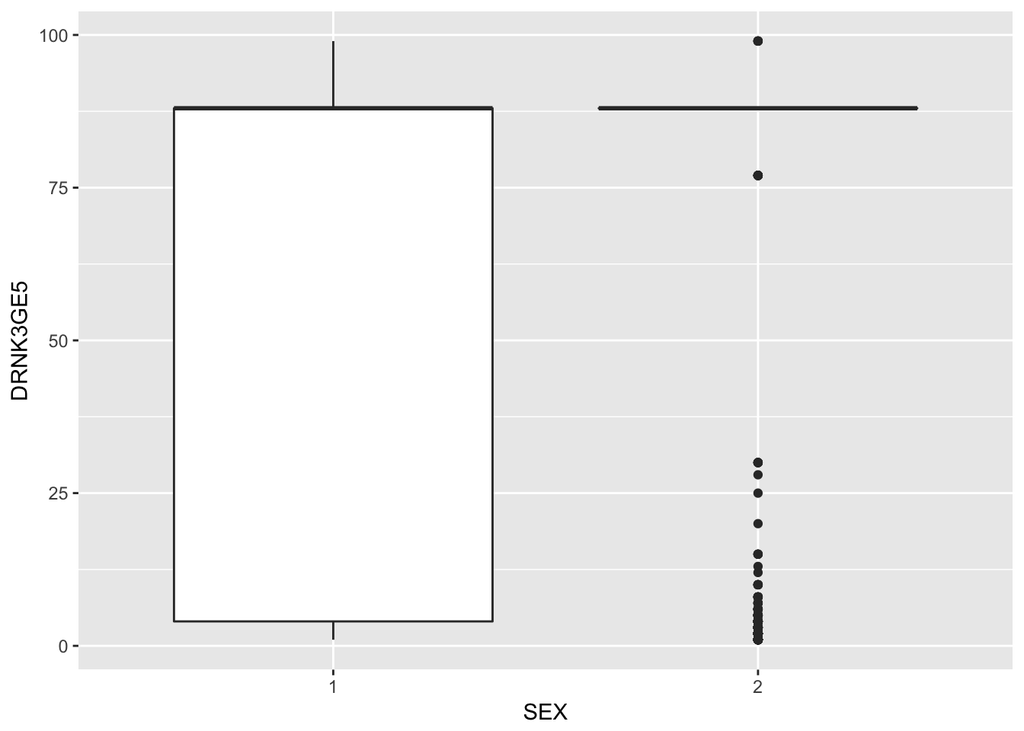

```r
qplot(data = iowa, x = SEX, y = DRNK3GE5, geom="boxplot")
```

2. It turns out that values 88, 99 and 77 have special meaning: 88 stands for “none”, 99 is “refused to answer” and 77 is “not sure”. Exclude these values from the boxplot.

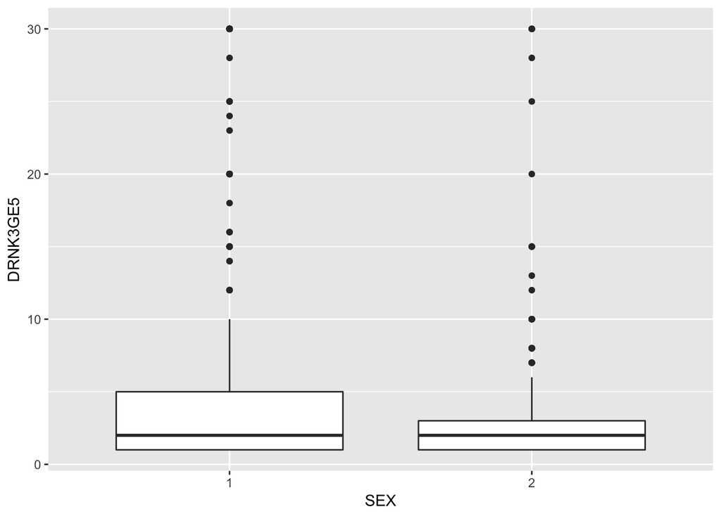

```r
qplot(data = subset(iowa, DRNK3GE5<77), x = SEX, y = DRNK3GE5, geom="boxplot")
```

3. Overlay jittered points for observed values onto this boxplot

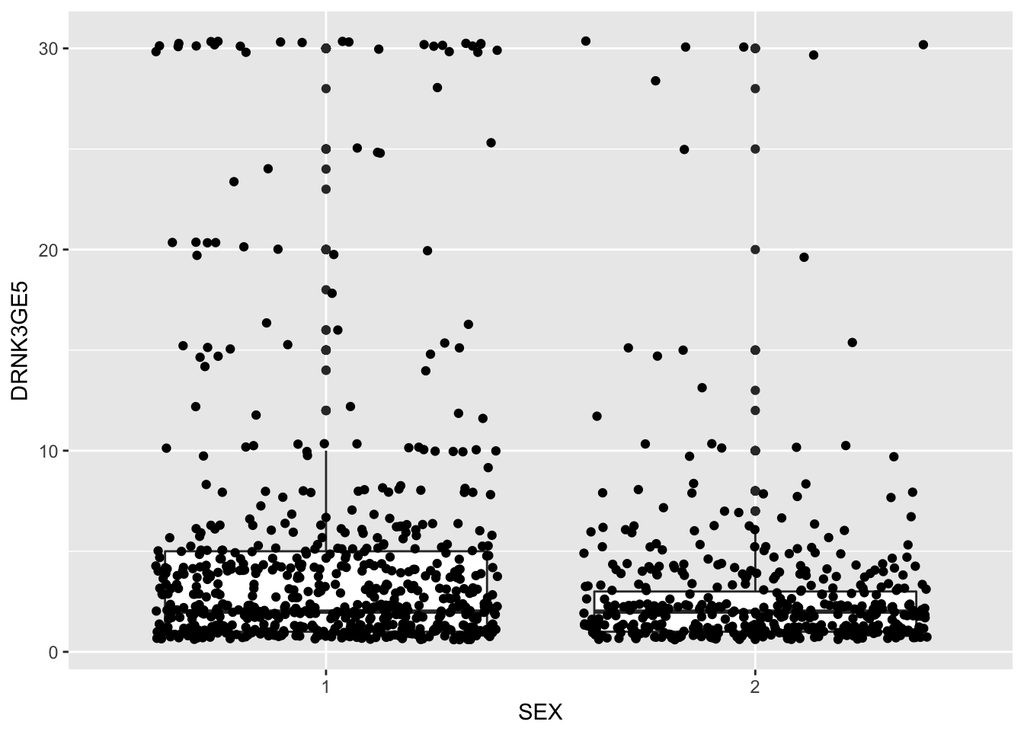

```r
qplot(data = subset(iowa, DRNK3GE5<77), x = SEX, y = DRNK3GE5, geom="boxplot") +
  geom_jitter()
```

## Seatbelt use

1. Use the brfss data to make a barplot for counts of seatbelt use (SEATBELT). *Seatbelt use (SEATBELT) is captured as 1 - Always, 2- Nearly Always, 3-Sometimes, 4- Seldom, 5-Never, 7-Don’t know, 8-Never drive or ride in a car, 9-Refused, to BLANK-Missing.*

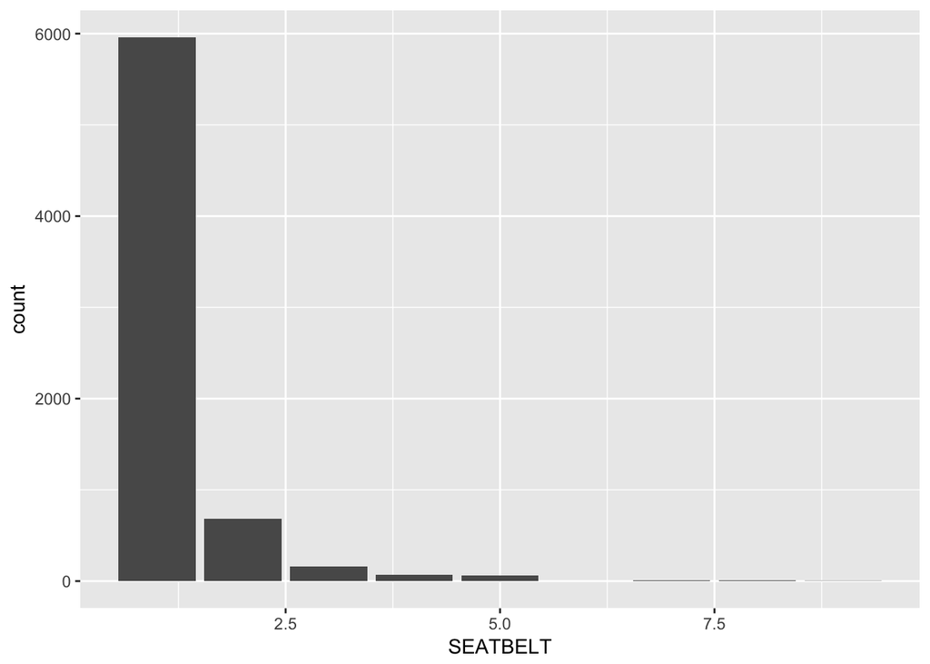

```r
qplot(data = iowa, x = SEATBELT, geom="bar")
```

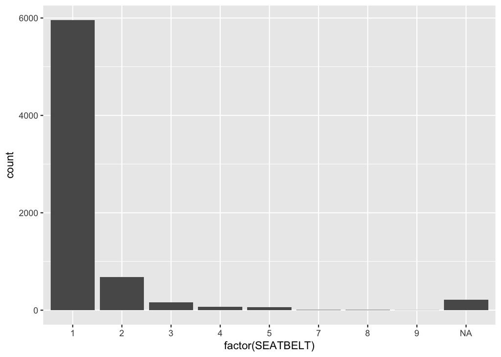

```r
qplot(data = iowa, x = factor(SEATBELT), geom="bar")
```

2. Facet seatbelt use by gender - are there gender differences in usage?

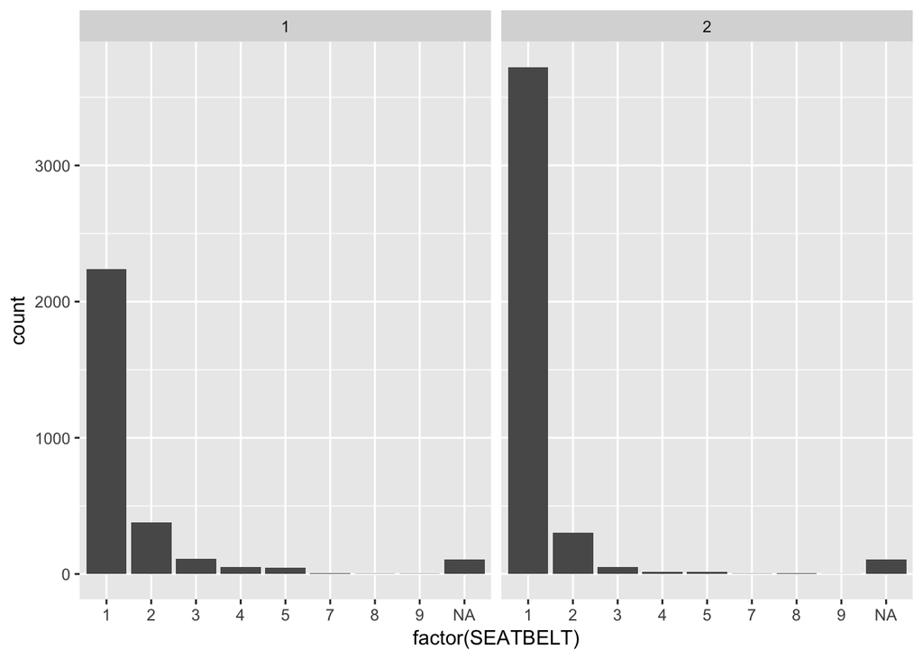

```r
qplot(data = iowa, x = factor(SEATBELT), geom="bar", facets=~SEX)
```

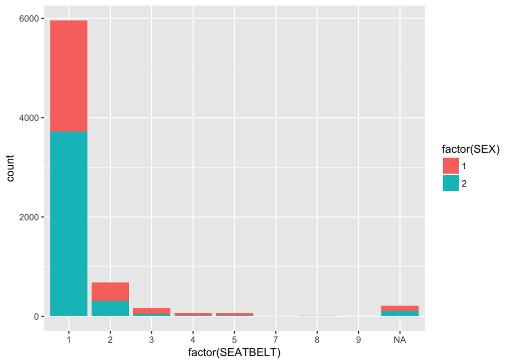

```r
# proportion of women always using a seatbelt is higher than proportion of men.
qplot(data = iowa, x = factor(SEATBELT), geom="bar", fill=factor(SEX))
```

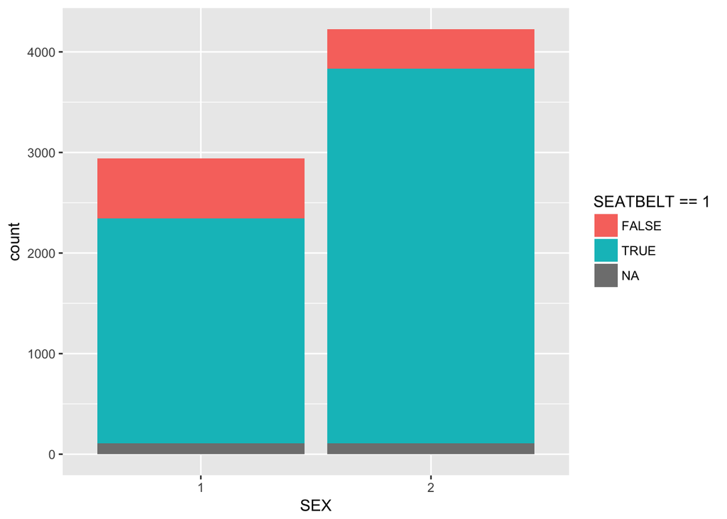

```r
qplot(data = iowa, x = SEX, geom="bar", fill=SEATBELT==1)
```

# Plot-Maps

Draw a map for the average number of alcoholic drinks per day for each gender

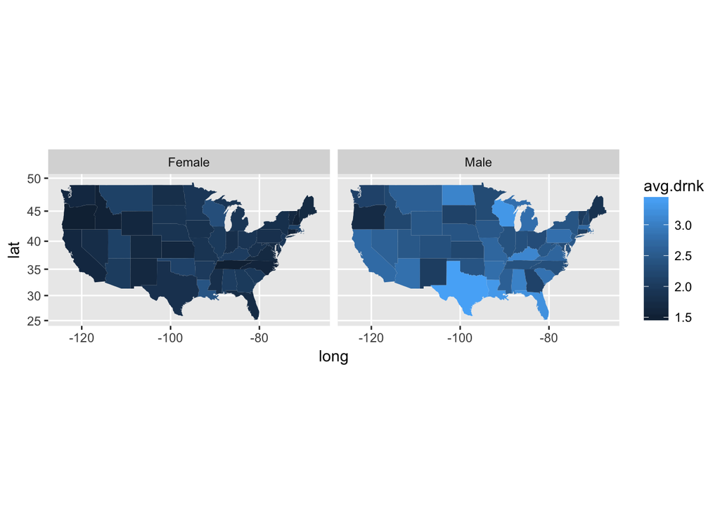

```r
library(ggplot2)
library(dplyr)
states <- map_data("state")

states.sex.stats <- read.csv("http://heike.github.io/rwrks/02-r-graphics/data/states.sex.stats.csv", stringsAsFactors = FALSE)
states.sex.map <- left_join(states, states.sex.stats, by = c("region" = "state.name"))

qplot(long, lat, geom = "polygon", data = states.sex.map,
      group = group, fill = avg.drnk) + coord_map() +
    facet_grid(. ~ sex)
```

Use options to polish the look of the average number of drinks by state by state!

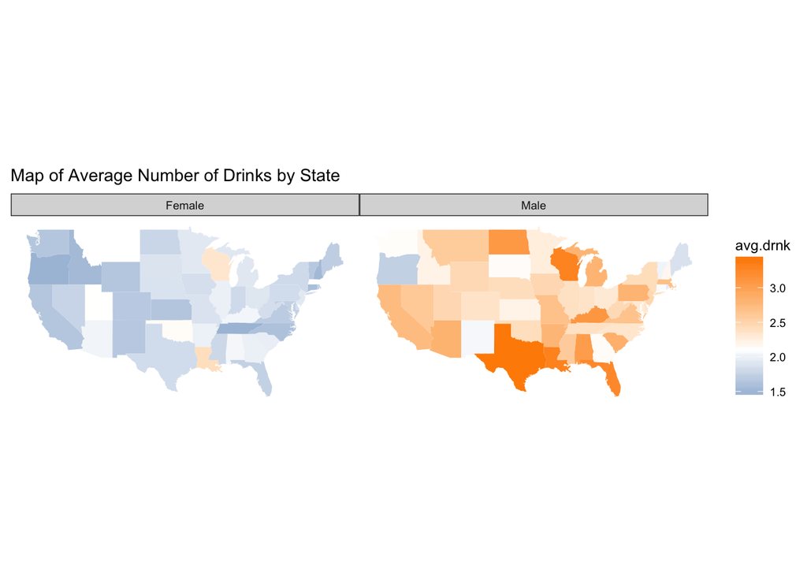

```r
qplot(long, lat, geom = "polygon", data = states.sex.map,
      group = group, fill = avg.drnk) + coord_map() +
    facet_grid(. ~ sex) +
  scale_fill_gradient2(midpoint=median(states.sex.stats$avg.drnk), low = "steelblue", high = "darkorange") +
  ggthemes::theme_map()  +
  ggtitle("Map of Average Number of Drinks by State") +
  theme(legend.position="right")
```

## Layers

Find the `ggplot()` statement that creates this plot:

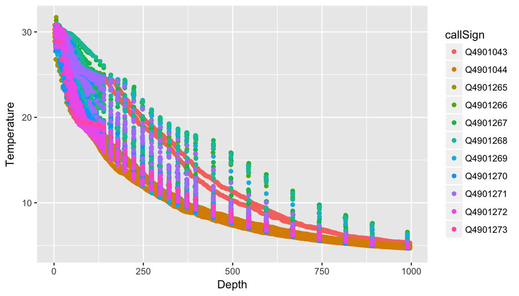

```r
load("../data/noaa.rdata")
ggplot(aes(x = Depth, y = Temperature, colour = callSign),
       data = floats) +
  geom_point()
```

1. Read in the animal.csv data:

```r
animal <- read.csv("https://raw.githubusercontent.com/heike/summerschool-2018/master/02-graphics/data/animal.csv")
```

2. Plot the location of animal sightings on a map of the region

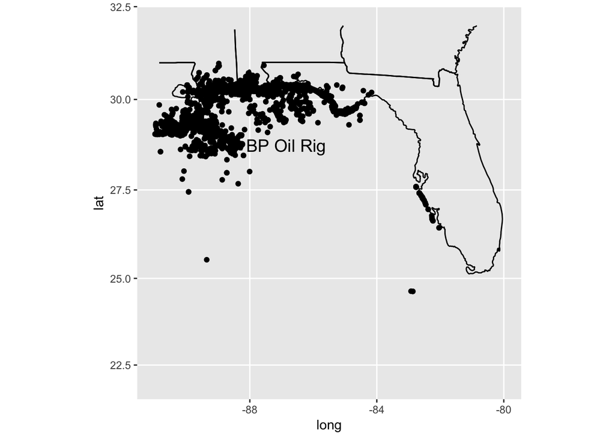

```r
ggplot() +
    geom_path(data = states, aes(x = long, y = lat, group = group)) +   geom_point(data = animal, aes(x = Longitude, y = Latitude)) +
    geom_point(aes(x, y), shape = "x", size = 5, data = rig) +
    geom_text(aes(x, y), label = "BP Oil Rig", size = 5, data = rig, hjust = -0.1) +
    xlim(c(-91, -80)) +
    ylim(c(22, 32)) + coord_map()
```